# Exercises

Import libraries and attach

```r
library(ISLR)
library(car)
attach(Auto)
```

## Excercise 8

```r
fit1 = lm(mpg ~ horsepower)
summary(fit1)
```

```
##
## Call:
## lm(formula = mpg ~ horsepower)
##
## Residuals:
##      Min       1Q   Median       3Q      Max
## -13.5710  -3.2592  -0.3435   2.7630  16.9240
##
## Coefficients:
##              Estimate Std. Error t value Pr(>|t|)
## (Intercept) 39.935861   0.717499   55.66   <2e-16 ***
## horsepower  -0.157845   0.006446  -24.49   <2e-16 ***
## ---
## Signif. codes:  0 '***' 0.001 '**' 0.01 '*' 0.05 '.' 0.1 ' ' 1
##
## Residual standard error: 4.906 on 390 degrees of freedom
## Multiple R-squared:  0.6059, Adjusted R-squared:  0.6049
## F-statistic: 599.7 on 1 and 390 DF,  p-value: < 2.2e-16
```

## 8.a.i

There is a relationship between horsepower and mpg because there is low p-value

### 8.a.ii

The relationship is very strong. p-value is very close to zero, denoted by ***.

### 8.a.iii

The relationship is negative because Estimate is negative (-0.15)

```r
#Prediction
predict(fit1, data.frame(horsepower=98), interval='prediction')
```

```
##        fit     lwr      upr
## 1 24.46708 14.8094 34.12476
```

```r
#Confidence
predict(fit1, data.frame(horsepower=98), interval='confidence')
```

```
##        fit      lwr      upr
## 1 24.46708 23.97308 24.96108
```

### 8.a.iv

For HP of 98, Predicted 24.5mpg. Confidence and Prediction intervals above

### 8.b

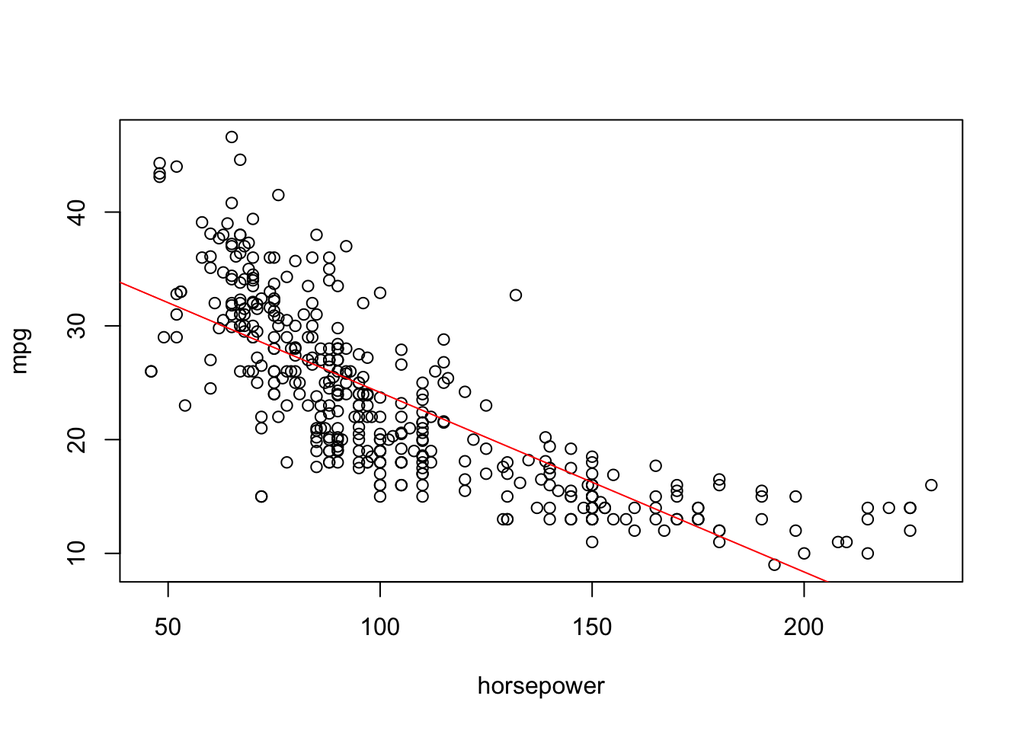

```r
plot(horsepower,mpg)
abline(fit1, col='red')
```

### 8.c

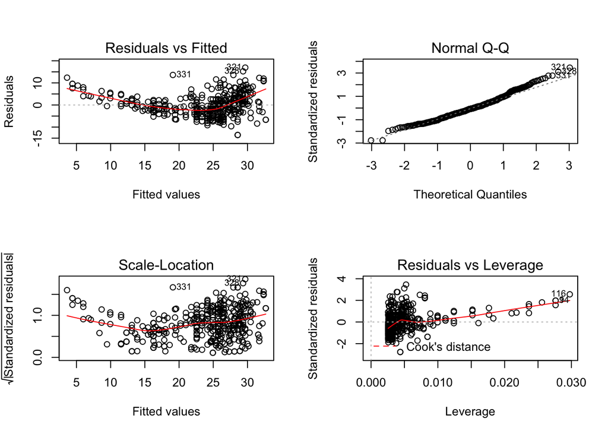

```r
par(mfrow=c(2,2))
plot(fit1)
```

### 8.c

There is a non-linear pattern in the fitted values that follows a parabola trajectory.